# Augmentation_Transverse_Crack

```python
import torch
import torchvision.transforms as transforms
from torchvision.utils import save_image
import cv2
from matplotlib import pyplot as plt
import numpy as np
from torchvision import transforms, models
from Augmentation_TAMIM import Load_Image, display_images, rotate, RandomFlip, centerCrop
```

```python
## load the image
img = Load_Image("D:\\SPRING 2023\\MS_Thesis\\MASTER'S THESIS\\DeepCrackModel\\EdmCrack600_DeepCrack\\codes\\data\\transverse_img\\15.png")
msk = Load_Image("D:\\SPRING 2023\\MS_Thesis\\MASTER'S THESIS\\DeepCrackModel\\EdmCrack600_DeepCrack\\codes\\data\\transverse_msk\\15.png")
```

```
(1080, 1920, 3) (1080, 1920, 3)
```

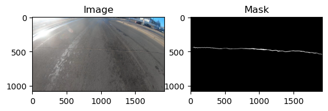

```python
img = np.array(img)
msk = np.array(msk)
print(img.shape, msk.shape)
display_images(img,msk)
```

# Rotate the image from 0 to 4 with 1 degree interval

Rotate the image to 0 degree (orginal)

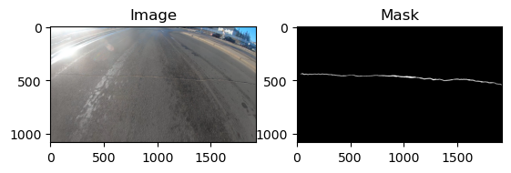

```python
img_rot_0, msk_rot_0 = rotate(img, msk, 0.0)
display_images(img_rot_0, msk_rot_0)
```

Rotate the image to 1 degree

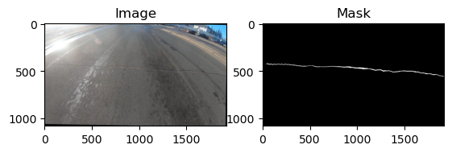

```python
img_rot_1, msk_rot_1 = rotate(img, msk, 1.0)
display_images(img_rot_1, msk_rot_1)
```

Rotate the image to 2 degree

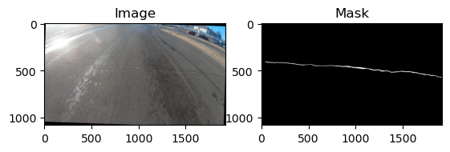

```python
img_rot_2, msk_rot_2 = rotate(img, msk, 2.0)
display_images(img_rot_2, msk_rot_2)
```

Rotate the image to 3 degree

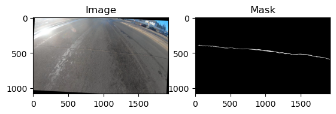

```python
img_rot_3, msk_rot_3 = rotate(img, msk, 3.0)
display_images(img_rot_3, msk_rot_3)
```

Rotate the image to 4 degree

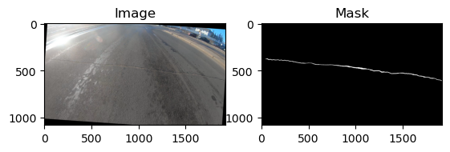

```python
img_rot_4, msk_rot_4 = rotate(img, msk, 4.0)
display_images(img_rot_4, msk_rot_4)
```

## CenterCrop Operation of the rotated images

Center Crop img_rot_0, msk_rot_0

```
(512, 512, 3) (512, 512, 3)
```

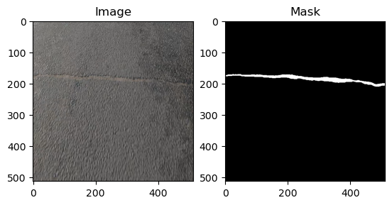

```python
crop_img_rot_0, crop_msk_rot_0 = centerCrop(img_rot_0, msk_rot_0, (512, 512) )
print(crop_img_rot_0.shape, crop_msk_rot_0.shape)
display_images(crop_img_rot_0, crop_msk_rot_0)
```

Center Crop img_rot_1, msk_rot_1

```
(512, 512, 3) (512, 512, 3)
```

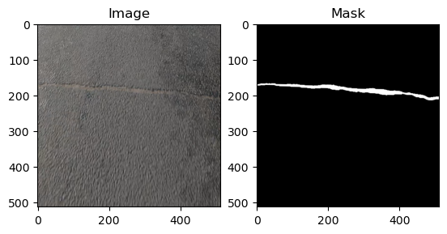

```python
crop_img_rot_1, crop_msk_rot_1 = centerCrop(img_rot_1, msk_rot_1, (512, 512) )
print(crop_img_rot_1.shape, crop_msk_rot_1.shape)
display_images(crop_img_rot_1, crop_msk_rot_1)
```

Center Crop img_rot_2, msk_rot_2

```
(512, 512, 3) (512, 512, 3)
```

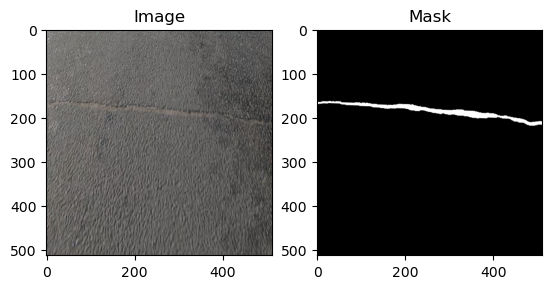

```python
crop_img_rot_2, crop_msk_rot_2 = centerCrop(img_rot_2, msk_rot_2, (512, 512) )
print(crop_img_rot_2.shape, crop_msk_rot_2.shape)
display_images(crop_img_rot_2, crop_msk_rot_2)
```

Center Crop img_rot_3, msk_rot_3

```
(512, 512, 3) (512, 512, 3)
```

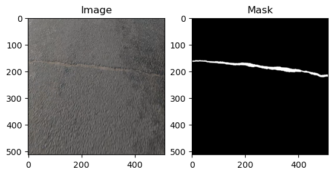

```python
crop_img_rot_3, crop_msk_rot_3 = centerCrop(img_rot_3, msk_rot_3, (512, 512) )
print(crop_img_rot_3.shape, crop_msk_rot_3.shape)
display_images(crop_img_rot_3, crop_msk_rot_3)
```

```
(512, 512, 3) (512, 512, 3)
```

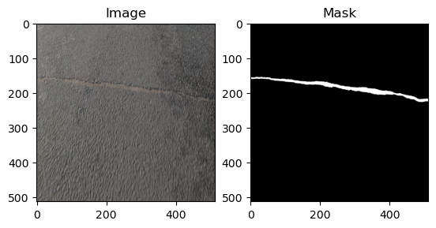

```python
crop_img_rot_4, crop_msk_rot_4 = centerCrop(img_rot_4, msk_rot_4, (512, 512) )
print(crop_img_rot_4.shape, crop_msk_rot_4.shape)
display_images(crop_img_rot_4, crop_msk_rot_4)
```

# Random_Flip top_down_left_Right = crop_img_rot_0, crop_msk_rot_0

crop_img_rot_0_filp_1, crop_img_rot_0_filp_2, crop_img_rot_0_filp_3, crop_img_rot_0_filp_4 crop_msk_rot_0_filp_1, crop_msk_rot_0_filp_2, crop_msk_rot_0_filp_3, crop_msk_rot_0_filp_4

```python
## Call the function
flp_img, flp_msk = RandomFlip(crop_img_rot_0, crop_msk_rot_0, FLIP_LEFT_RIGHT=True, FLIP_TOP_BOTTOM=True)

flp_img = cv2.cvtColor(flp_img, cv2.COLOR_RGB2BGR)
flp_msk = cv2.cvtColor(flp_msk, cv2.COLOR_RGB2BGR)

# make axes: images are arranged over one row
fig, (ax1, ax2) = plt.subplots(nrows=1, ncols=2)

# you can change the size of the plot is required
fig_size = (12, 10)  # example base size

fig.set_figwidth(fig_size[0] * 2)  # where 2 is #columns
fig.set_figheight(fig_size[1] * 2)  # 2 is #rows

# plot the images on each axis
ax1.imshow(crop_img_rot_0)      ## Original
ax1.imshow(flp_img)  ## new image

# additionally you can specify a colormap, e.g.
ax2.imshow(crop_msk_rot_0, cmap='binary')
ax2.imshow(flp_msk, cmap='binary')  ## new image

# you can set the title, axis labels, legends, as usual, e.g.
ax1.set_title('Image')
ax2.set_title('Mask')

# removes borders
fig.tight_layout()

# finally show the images
plt.show()

## Saving the images


cv2.imwrite("crop_img_rot_0_filp_10.JPG", flp_img)
cv2.imwrite("crop_img_rot_0_filp_10.png", flp_msk)
```

[output not shown]

# Random_Flip top_down_left_Right = crop_img_rot_1, crop_msk_rot_1

crop_img_rot_1_filp_1, crop_img_rot_1_filp_2, crop_img_rot_1_filp_3, crop_img_rot_1_filp_4 crop_msk_rot_1_filp_1, crop_msk_rot_1_filp_2, crop_msk_rot_1_filp_3, crop_msk_rot_1_filp_4

```python
## Call the function
flp_img, flp_msk = RandomFlip(crop_img_rot_1, crop_msk_rot_1, FLIP_LEFT_RIGHT=True, FLIP_TOP_BOTTOM=True)

flp_img = cv2.cvtColor(flp_img, cv2.COLOR_RGB2BGR)
flp_msk = cv2.cvtColor(flp_msk, cv2.COLOR_RGB2BGR)

# make axes: images are arranged over one row
fig, (ax1, ax2) = plt.subplots(nrows=1, ncols=2)

# you can change the size of the plot is required
fig_size = (12, 10)  # example base size

fig.set_figwidth(fig_size[0] * 2)  # where 2 is #columns
fig.set_figheight(fig_size[1] * 2)  # 2 is #rows

# plot the images on each axis
ax1.imshow(crop_img_rot_1)      ## Original
ax1.imshow(flp_img)  ## new image

# additionally you can specify a colormap, e.g.
ax2.imshow(crop_msk_rot_1, cmap='binary')
ax2.imshow(flp_msk, cmap='binary')  ## new image

# you can set the title, axis labels, legends, as usual, e.g.
ax1.set_title('Image')
ax2.set_title('Mask')

# removes borders
fig.tight_layout()

# finally show the images
plt.show()

## Saving the images


cv2.imwrite("crop_img_rot_1_filp_10.JPG", flp_img)
cv2.imwrite("crop_img_rot_1_filp_10.png", flp_msk)
```

[output not shown]

# Random_Flip top_down_left_Right = crop_img_rot_2, crop_msk_rot_2

crop_img_rot_2_filp_1, crop_img_rot_2_filp_2, crop_img_rot_2_filp_3, crop_img_rot_2_filp_4 crop_msk_rot_2_filp_1, crop_msk_rot_2_filp_2, crop_msk_rot_2_filp_3, crop_msk_rot_2_filp_4

```python
## Call the function
flp_img, flp_msk = RandomFlip(crop_img_rot_2, crop_msk_rot_2, FLIP_LEFT_RIGHT=True, FLIP_TOP_BOTTOM=True)

flp_img = cv2.cvtColor(flp_img, cv2.COLOR_RGB2BGR)
flp_msk = cv2.cvtColor(flp_msk, cv2.COLOR_RGB2BGR)

# make axes: images are arranged over one row
fig, (ax1, ax2) = plt.subplots(nrows=1, ncols=2)

# you can change the size of the plot is required
fig_size = (12, 10)  # example base size

fig.set_figwidth(fig_size[0] * 2)  # where 2 is #columns
fig.set_figheight(fig_size[1] * 2)  # 2 is #rows

# plot the images on each axis
ax1.imshow(crop_img_rot_2)      ## Original
ax1.imshow(flp_img)  ## new image

# additionally you can specify a colormap, e.g.
ax2.imshow(crop_msk_rot_2, cmap='binary')
ax2.imshow(flp_msk, cmap='binary')  ## new image

# you can set the title, axis labels, legends, as usual, e.g.
ax1.set_title('Image')
ax2.set_title('Mask')

# removes borders
fig.tight_layout()

# finally show the images
plt.show()

## Saving the images


cv2.imwrite("crop_img_rot_2_filp_10.JPG", flp_img)
cv2.imwrite("crop_img_rot_2_filp_10.png", flp_msk)
```

[output not shown]

# Random_Flip top_down_left_Right = crop_img_rot_3, crop_msk_rot_3

crop_img_rot_3_filp_1, crop_img_rot_3_filp_2, crop_img_rot_3_filp_3, crop_img_rot_3_filp_4 crop_msk_rot_3_filp_1, crop_msk_rot_3_filp_2, crop_msk_rot_3_filp_3, crop_msk_rot_3_filp_4

```python
## Call the function
flp_img, flp_msk = RandomFlip(crop_img_rot_3, crop_msk_rot_3, FLIP_LEFT_RIGHT=True, FLIP_TOP_BOTTOM=True)

flp_img = cv2.cvtColor(flp_img, cv2.COLOR_RGB2BGR)
flp_msk = cv2.cvtColor(flp_msk, cv2.COLOR_RGB2BGR)

# make axes: images are arranged over one row
fig, (ax1, ax2) = plt.subplots(nrows=1, ncols=2)

# you can change the size of the plot is required
fig_size = (12, 10)  # example base size

fig.set_figwidth(fig_size[0] * 2)  # where 2 is #columns
fig.set_figheight(fig_size[1] * 2)  # 2 is #rows

# plot the images on each axis
ax1.imshow(crop_img_rot_3)      ## Original
ax1.imshow(flp_img)  ## new image

# additionally you can specify a colormap, e.g.
ax2.imshow(crop_msk_rot_3, cmap='binary')
ax2.imshow(flp_msk, cmap='binary')  ## new image

# you can set the title, axis labels, legends, as usual, e.g.
ax1.set_title('Image')
ax2.set_title('Mask')

# removes borders
fig.tight_layout()

# finally show the images
plt.show()

## Saving the images


cv2.imwrite("crop_img_rot_3_filp_10.JPG", flp_img)
cv2.imwrite("crop_img_rot_3_filp_10.png", flp_msk)
```

[output not shown]

# Random_Flip top_down_left_Right = crop_img_rot_4, crop_msk_rot_4

crop_img_rot_4_filp_1, crop_img_rot_4_filp_2, crop_img_rot_4_filp_3, crop_img_rot_4_filp_4 crop_msk_rot_4_filp_1, crop_msk_rot_4_filp_2, crop_msk_rot_4_filp_3, crop_msk_rot_4_filp_4

```python
## Call the function
flp_img, flp_msk = RandomFlip(crop_img_rot_4, crop_msk_rot_4, FLIP_LEFT_RIGHT=True, FLIP_TOP_BOTTOM=True)

flp_img = cv2.cvtColor(flp_img, cv2.COLOR_RGB2BGR)
flp_msk = cv2.cvtColor(flp_msk, cv2.COLOR_RGB2BGR)

# make axes: images are arranged over one row
fig, (ax1, ax2) = plt.subplots(nrows=1, ncols=2)

# you can change the size of the plot is required
fig_size = (12, 10)  # example base size

fig.set_figwidth(fig_size[0] * 2)  # where 2 is #columns
fig.set_figheight(fig_size[1] * 2)  # 2 is #rows

# plot the images on each axis
ax1.imshow(crop_img_rot_4)      ## Original
ax1.imshow(flp_img)  ## new image

# additionally you can specify a colormap, e.g.
ax2.imshow(crop_msk_rot_4, cmap='binary')
ax2.imshow(flp_msk, cmap='binary')  ## new image

# you can set the title, axis labels, legends, as usual, e.g.
ax1.set_title('Image')
ax2.set_title('Mask')

# removes borders
fig.tight_layout()

# finally show the images
plt.show()

## Saving the images


cv2.imwrite("crop_img_rot_4_filp_10.JPG", flp_img)
cv2.imwrite("crop_img_rot_4_filp_10.png", flp_msk)
```

[output not shown]